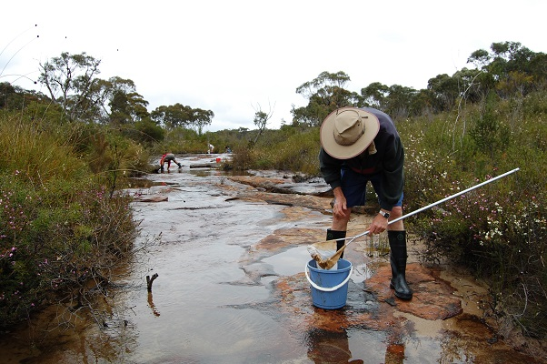

An environmental scientist was interested in how land management affected water quality in rivers. She compared the salinity of 10 rivers in areas of farmland to 10 rivers in forested areas and received the following data (measured as EC, electrical conductivity):

Landscape EC Forest 307 Forest 298 Forest 478 Forest 687 Forest 523 Forest 380 Forest 475 Forest 463 Forest 391 Forest 370 Farmland 850 Farmland 551 Farmland 639 Farmland 567 Farmland 403 Farmland 578 Farmland 601 Farmland 490 Farmland 647 Farmland 612

```r
RiverEC = read.csv(file = "RiverEC.csv", header = T)
```

Firstly, visualise the differences in electrical conductivity abundance between the two types of rivers.

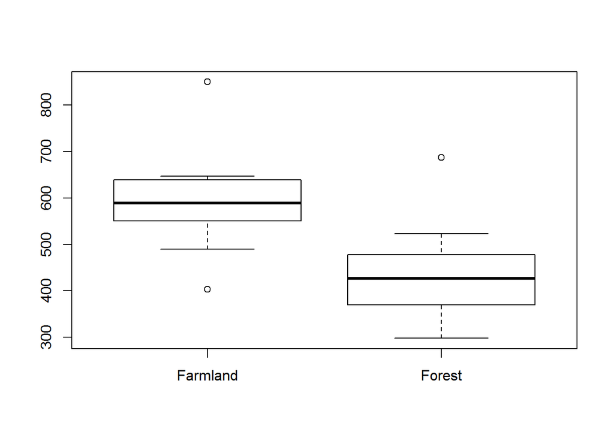

```r
boxplot(EC~Landscape, data = RiverEC)
```

**Q1** What statistical test would be suitable to contrast the salinity between the two types of rivers?

```r
# {1:MULTICHOICE:=Two sample t test~Contingency table~Goodness of fit test~Paired t test}
```

**Q2** After checking the assumptions of your test, conduct the test, and give the value of the test statistic and P value.

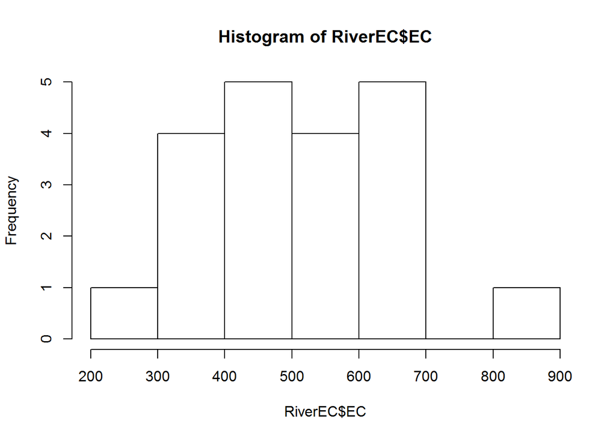

```r
hist(RiverEC$EC)
```

```r
t.test(EC~Landscape, data = RiverEC)
```

```
##
##  Welch Two Sample t-test
##
## data:  EC by Landscape
## t = 3.029, df = 18, p-value = 0.007224
## alternative hypothesis: true difference in means is not equal to 0
## 95 percent confidence interval:
##   47.96 265.24
## sample estimates:
## mean in group Farmland   mean in group Forest
##                  593.8                  437.2
```

**Q3** Is there any evidence that salinity varied between the rivers in farmland and forest?

```r
# {1:MULTICHOICE:=Yes~No}
```

Samples were also classified into those that were above or below the limit recommended by the World Health Organisation for drinking water (EC= 800).

**Q4** What analysis could you use to test the whether the 20 samples differed from previous sampling in the same area that had found 40% of samples unsuitable for drinking?

```r
sum(RiverEC$EC >= 800) # Counts how many observation over 800
```

```
## [1] 1
```

```r
chisq.test(x=c(1,19),p=c(0.4,0.6))
```

```
##
##  Chi-squared test for given probabilities
##
## data:  c(1, 19)
## X-squared = 10.21, df = 1, p-value = 0.001398
```

**Q5** Present the value of the test statistic chosen and state whether the null hypothesis is rejected or retained.